# Analyze_trip_data

Juliette

12/03/2021

## Analyzing cyclistic fictional trip data

This documents explores how different customers for a fictional company called Cyclistic are using their ride-share program in the last twelve months from August 2020 to July 2021. The data was stored in individual excel files by month. The data is owned and licensed by Motivate International Inc (https://divvy-tripdata.s3.amazonaws.com/index.html)

## Load packages

Here I load the packages for analysis

```r
library(tidyverse)
```

```r
library(dplyr)
library(ggplot2)
library(lubridate)
library(scales)
```

### Load and merge files

Here I load and merge the 12 excel files

```r
library(data.table)
setwd("C:/Users/julie/OneDrive/Documents/trip/Cyclist")
files <- list.files(pattern = ".csv")
data <- lapply(files, fread, sep= ",")
trip_data <- rbindlist(data)
```

### Clean data

Here I start cleaning the data, removing empty columns, spaces, looking for duplicates

```r
### remove N/A columns and empty columns
trip_data2 <- filter(trip_data, start_station_id != "NA" & end_station_id!="NA")
trip_data3 <-  filter(trip_data, start_station_name != "" & end_station_name!="")

### check for  duplicates
ride_id <- trip_data3 %>%
  count(ride_id) %>%
  filter(n > 1) # no duplicates found
```

## Transform data

Here I start transforming the data for next step in analysis

Here I find ride length between start and end stations in minutes

```r
trip_data3$ride_length <- difftime(
  trip_data3$ended_at,
  trip_data3$started_at,
  units = "mins"
)
```

### Remove ride length < 0

Here I remove values less than zero that can negatively skew the results

```r
trip_data3 <- trip_data3 %>%
  filter(!(ride_length < 0))
```

### Create column for day of the week, month, year

Here I create three columns, one for the days of the week, month and year

```r
trip_data3$day_of_week <- format(trip_data3$started_at,
                                "%A")
trip_data3$day_of_week <- ordered(trip_data3$day_of_week, levels=c("Sunday", "Monday", "Tuesday", "Wednesday", "Thursday", "Friday", "Saturday"))
trip_data3$month <- format(trip_data3$started_at, "%m")
trip_data3$year <- format(trip_data3$started_at, "%y")
trip_data3$hour <- format(trip_data3$started_at, "%H:%M:%S")
```

### Select variables to work with

Here I select subset of variables to work with in next step of analysis

```r
trip_variables <- trip_data3 %>%
  select(ride_id, rideable_type,started_at, start_station_name, end_station_name, member_casual,hour, ride_length, day_of_week, year, month)
```

## Analyze members and casual riders

Here I start looking for similarities and differences among member and casual riders

### Common start station trips for members

Here I create a data frame that includes common start station trips for members

```r
trip_variables %>%
  select (start_station_name, member_casual) %>%
  group_by(start_station_name)%>%
  filter(member_casual == "member")%>%
  mutate(trips = n()) %>%
  distinct(start_station_name, .keep_all = TRUE)
```

```
## # A tibble: 714 x 3
## # Groups:   start_station_name [714]
##    start_station_name               member_casual trips
##    <chr>                            <chr>         <int>
##  1 Lake Shore Dr & Diversey Pkwy    member        10445
##  2 Marine Dr & Ainslie St           member         4951
##  3 Dearborn St & Erie St            member        17634
##  4 Wells St & Elm St                member        18256
##  5 Desplaines St & Kinzie St        member        15679
##  6 Wallace St & 35th St             member         1675
##  7 Broadway & Granville Ave         member         4713
##  8 Lake Park Ave & 56th St          member         3355
##  9 Clark St & 9th St (AMLI)         member         3593
## 10 Cottage Grove Ave & Oakwood Blvd member          925
## # ... with 704 more rows
```

### Common end station trips for members

Here I create a data frame for common end station trips for members

```r
 trip_variables %>%
  select (end_station_name, member_casual) %>%
  group_by(end_station_name)%>%
  filter(member_casual == "member")%>%
  mutate(trips = n()) %>%
  distinct(end_station_name, .keep_all = TRUE)
```

```
## # A tibble: 713 x 3
## # Groups:   end_station_name [713]
##    end_station_name                 member_casual trips
##    <chr>                            <chr>         <int>
##  1 Clark St & Lincoln Ave           member        14664
##  2 Sheridan Rd & Lawrence Ave       member         3550
##  3 Kingsbury St & Erie St           member        12260
##  4 State St & Van Buren St          member         3993
##  5 Cottage Grove Ave & Oakwood Blvd member          882
##  6 Broadway & Granville Ave         member         4855
##  7 Stony Island Ave & 71st St       member           80
##  8 Lake Park Ave & 56th St          member         3554
##  9 Wallace St & 35th St             member         1652
## 10 Clark St & Schiller St           member        12169
## # ... with 703 more rows
```

### Common start station trips for casual riders

Here I create a data frame for common start station trips among casual riders

```r
 trip_variables %>%
  select (start_station_name, member_casual)%>%
  group_by (start_station_name)%>%
  filter(member_casual == "casual")%>%
  mutate(trips = n()) %>%
  distinct(start_station_name, .keep_all= TRUE)
```

```
## # A tibble: 727 x 3
## # Groups:   start_station_name [727]
##    start_station_name              member_casual trips
##    <chr>                           <chr>         <int>
##  1 Michigan Ave & 14th St          casual         5068
##  2 Columbus Dr & Randolph St       casual        11467
##  3 Daley Center Plaza              casual         6052
##  4 Leavitt St & Division St        casual         1147
##  5 Cityfront Plaza Dr & Pioneer Ct casual         6494
##  6 Sheffield Ave & Fullerton Ave   casual         4918
##  7 Southport Ave & Wellington Ave  casual         4405
##  8 Theater on the Lake             casual        21812
##  9 Lakeview Ave & Fullerton Pkwy   casual        10840
## 10 Morgan St & Lake St             casual         6931
## # ... with 717 more rows
```

### Common end station trips for casual riders

Here I create a data frame for common end stations trips for casual riders

```r
trip_variables %>%
  select (end_station_name, member_casual)%>%
  group_by (end_station_name)%>%
  filter(member_casual == "casual")%>%
  mutate(trips = n()) %>%
  distinct(end_station_name, .keep_all= TRUE)
```

```
## # A tibble: 727 x 3
## # Groups:   end_station_name [727]
##    end_station_name          member_casual trips
##    <chr>                     <chr>         <int>
##  1 Michigan Ave & 14th St    casual         5075
##  2 State St & Randolph St    casual         9099
##  3 State St & Kinzie St      casual         9482
##  4 Leavitt St & Division St  casual         1016
##  5 Dearborn St & Monroe St   casual         5588
##  6 Southport Ave & Roscoe St casual         7609
##  7 Halsted St & Dickens Ave  casual         6646
##  8 Western Ave & Division St casual         1948
##  9 Broadway & Belmont Ave    casual         6870
## 10 LaSalle St & Jackson Blvd casual         2166
## # ... with 717 more rows
```

```r
trip_variables %>%
  select(
    member_casual,
    month) %>%
  group_by(member_casual,) %>%
  mutate( trips = n()) %>%
  distinct(
    month,
    member_casual,
    .keep_all = TRUE
  )
```

```
## # A tibble: 24 x 3
## # Groups:   member_casual [2]
##    member_casual month   trips
##    <chr>         <chr>   <int>
##  1 member        08    2333635
##  2 casual        08    1826594
##  3 casual        09    1826594
##  4 member        09    2333635
##  5 casual        10    1826594
##  6 member        10    2333635
##  7 casual        11    1826594
##  8 member        11    2333635
##  9 member        12    2333635
## 10 casual        12    1826594
## # ... with 14 more rows
```

```r
 trip_variables %>%
  select(
    member_casual, year) %>%
  group_by(member_casual) %>%
  mutate(trips = n()) %>%
  distinct(
    year,
    member_casual,
    .keep_all = TRUE
  )
```

```
## # A tibble: 4 x 3
## # Groups:   member_casual [2]
##   member_casual year    trips
##   <chr>         <chr>   <int>
## 1 member        20    2333635
## 2 casual        20    1826594
## 3 member        21    2333635
## 4 casual        21    1826594
```

## Visualization

### Summarize member casual ride length, group by member_casual

Here I summarize ride length by customer type

```r
trip_variables %>%
  select(member_casual, ride_length)%>%
  group_by(member_casual) %>%
  summarize(mean(ride_length), sd(ride_length)) # casual members ride longer than members
```

```
## # A tibble: 2 x 3
##   member_casual `mean(ride_length)` `sd(ride_length)`
##   <chr>         <drtn>                          <dbl>
## 1 casual        37.56549 mins                   335.
## 2 member        14.38951 mins                    51.2
```

### Visualize member and casual riders

Here I visualize member and casual riders

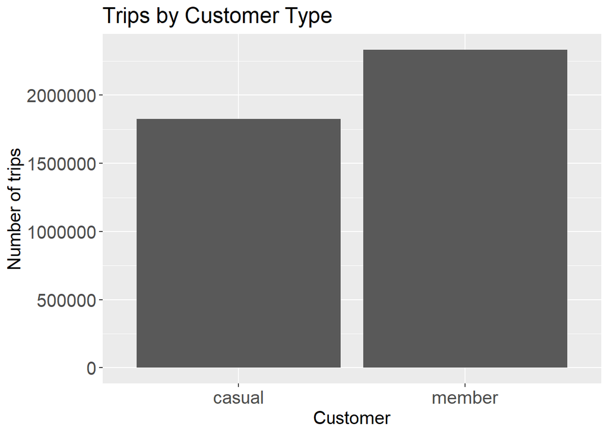

```r
ggplot(data = trip_variables) +
  geom_bar(mapping = aes(x = member_casual))+
labs(title = "Trips by Customer Type" ) +
  xlab("Customer") + ylab("Number of trips") +
  theme(text = element_text(size=15), axis.text = element_text(size=15),legend.text=element_text(size=15))
```

### Group by rideable_type

Here I group customer by type of bikes used

```r
trip_variables %>%
  group_by(member_casual, rideable_type) %>%
  summarize(mean(ride_length))
```

```
## # A tibble: 6 x 3
## # Groups:   member_casual [2]
##   member_casual rideable_type `mean(ride_length)`
##   <chr>         <chr>         <drtn>
## 1 casual        classic_bike  27.39723 mins
## 2 casual        docked_bike   54.92282 mins
## 3 casual        electric_bike 21.40788 mins
## 4 member        classic_bike  14.11236 mins
## 5 member        docked_bike   15.54795 mins
## 6 member        electric_bike 13.03680 mins
```

### Types of bikes riders use

Here I plot types of bikes used by riders

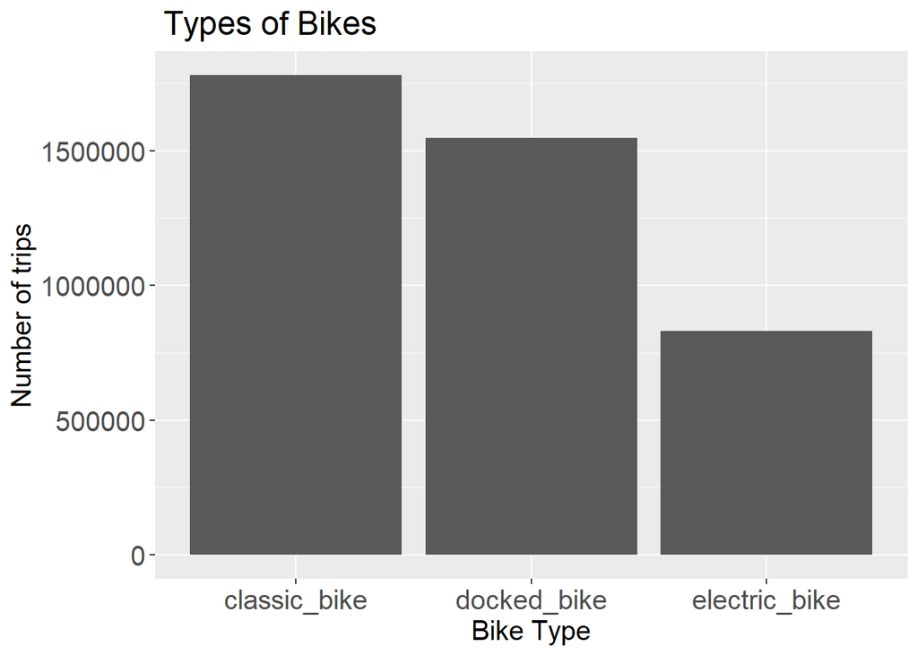

```r
ggplot(data = trip_variables) +
  geom_bar(mapping = aes(x = rideable_type))+
labs(title = " Types of Bikes" ) +
  xlab("Bike Type") + ylab("Number of trips") +
  theme(text = element_text(size=15), axis.text = element_text(size=15),legend.text=element_text(size=15))
```

```r
# most popular bike is the classic bike followed, by the docked bike, and lastly the electric bike
```

### Compare member and casual riders to types of bikes used

Here I compare member and casual riders to types of bikes used

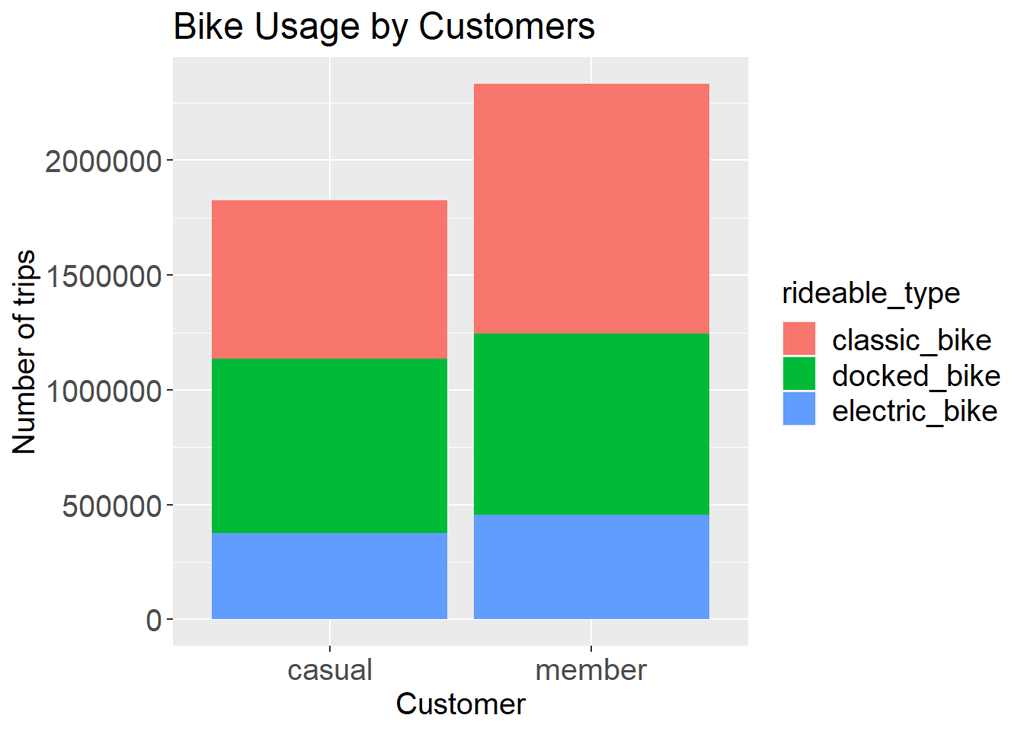

```r
ggplot(data = trip_variables) +
  geom_bar(mapping = aes(x = member_casual, fill=rideable_type))+
labs(title = "Bike Usage by Customers" ) +
  xlab("Customer") + ylab("Number of trips") +
  theme(text = element_text(size=15), axis.text = element_text(size=15),legend.text=element_text(size=15))
```

```r
# members take more trips with the classic bike and docked bike compared to casual customers
```